# CDE-R: Import, Clean, and Analyze

April 24, 2019

## Outline

### What we'll cover today

- Intro & general tips
- S1: `R-core`: un-wrapping a table of data
- S2: `tidyverse`: reading census xlsx
- S3: `tidyverse`: sex and violins

## General Tips 1

- Be practical: use the best tool you are comfortable with (where possible)
- Learn to navigate with and run basic command in `Terminal.app` or [WSL](https://docs.microsoft.com/en-us/windows/wsl/install-win10)
- Be humble: Look for answers and ask for help
- Use version control (`git`) or at least a cloud-sync backup (Dropbox, GDrive)
- Minimize the amount of manual processing of data / results

## General Tips 2

- Use consistent [style](https://style.tidyverse.org)
- Use comments to document your code
- Use variable names that are unique and identifying
  - e.g. `temps` or `temperatures` instead of `x` or `v1`
- Avoid hard-coded, repetitive code
  - Write functions to re-use code

## What R is

- Interpreted, object-oriented language
- Optimized matrix/vector functions
- Large and diverse package community
  - [CRAN](https://cran.r-project.org/web/packages/), [Bioconductor](https://www.bioconductor.org/), Github

## What R isn't

- Beginner friendly
- General purpose
- Memory efficient

## `R` Tips

- Use RStudio where available (when performance isn't important)
- Avoid but do not fear loops (they've gotten better)
- Use and request **tidy data**[Wickham, H. "Tidy Data" J. Stat. Soft., 2014](https://www.jstatsoft.org/article/view/v059i10)
- Each variable is a column
- Each observation or case is a row
- pivot / hierarchical tables are for presentation, not analysis

*Reminder*: R uses `NA` for character and numeric data (Unlike SAS).

## S1: Publication formatted table

Scenario 1: You're given the pasted text from a manuscript table to analyze

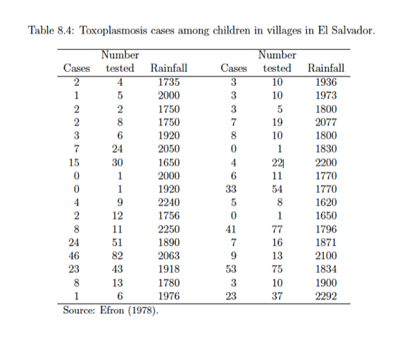

Toxoplasmosis Table

## S1: Raw Text

data/toxoplasmosis.txt

```
  2  4   1735  3   10   1936

  1  5   2000  3   10   1973

  2  2   1750  3    5   1800

  2  8   1750  7   19   2077
...
```

## S1: Read the table

*Reminder*: `read.table` skips empty lines

```r
colnames <- c("Cases", "tested", "Rainfall")
toxo <- read.table(file="data/toxoplasmosis.txt")
names(toxo) <- rep(colnames, 2)
toxo
```

| Cases | tested | Rainfall | Cases | tested | Rainfall |
| --- | --- | --- | --- | --- | --- |
| 2 | 4 | 1735 | 3 | 10 | 1936 |
| 1 | 5 | 2000 | 3 | 10 | 1973 |
| 2 | 2 | 1750 | 3 | 5 | 1800 |
| 2 | 8 | 1750 | 7 | 19 | 2077 |
| 3 | 6 | 1920 | 8 | 10 | 1800 |
| 7 | 24 | 2050 | 0 | 1 | 1830 |
| 15 | 30 | 1650 | 4 | 22 | 2200 |
| 0 | 1 | 2000 | 6 | 11 | 1770 |
| 0 | 1 | 1920 | 33 | 54 | 1770 |
| 4 | 9 | 2240 | 5 | 8 | 1620 |

[output cut: 7 more lines]

## S1: Stitch back together

```r
toxo <- rbind(toxo[,1:3], toxo[,4:6])
summary(toxo)
```

```
     Cases           tested         Rainfall
 Min.   : 0.00   Min.   : 1.00   Min.   :1620
 1st Qu.: 2.00   1st Qu.: 6.00   1st Qu.:1772
 Median : 4.50   Median :10.50   Median :1895
 Mean   :10.47   Mean   :20.21   Mean   :1908
 3rd Qu.: 8.75   3rd Qu.:23.50   3rd Qu.:2000
 Max.   :53.00   Max.   :82.00   Max.   :2292
```

## S2: Census data from Excel

Scenario 2: you are given an Excel file with census data [from census.gov](https://www.census.gov/newsroom/press-kits/2018/pop-estimates-national-state.html), retrieved Apr 22, 2019 to analyze.

Let's try using the [`readxl`](https://readxl.tidyverse.org/) package

## S2: Read in the data

```r
#install.packages(c("tidyverse","readxl"))
library(readxl)
census_xlsx <- read_excel("data/nst-est2018-01.xlsx")
```

```
New names:
* `` -> ...2
* `` -> ...3
* `` -> ...4
* `` -> ...5
* `` -> ...6
* … and 6 more problems
```

## S2: what went wrong?

```r
census_xlsx
```

| table with row headers in column A and column headers in rows 3 through 4. (leading dots indicate sub-parts) | ...2 | ...3 | ...4 | ...5 | ...6 | ...7 | ...8 | ...9 | ...10 | ...11 | ...12 |
| --- | --- | --- | --- | --- | --- | --- | --- | --- | --- | --- | --- |
| Table 1. Annual Estimates of the Resident Population for the United States, Regions, States, and Puerto Rico: April 1, 2010 to July 1, 2018 | NA | NA | NA | NA | NA | NA | NA | NA | NA | NA | NA |
| Geographic Area | 40269 | NA | Population Estimate (as of July 1) | NA | NA | NA | NA | NA | NA | NA | NA |
| NA | Census | Estimates Base | 2010 | 2011 | 2012 | 2013 | 2014 | 2015 | 2016 | 2017 | 2018 |
| United States | 308745538 | 308758105 | 309326085 | 311580009 | 313874218 | 316057727 | 318386421 | 320742673 | 323071342 | 325147121 | 327167434 |
| Northeast | 55317240 | 55318430 | 55380645 | 55600532 | 55776729 | 55907823 | 56015864 | 56047587 | 56058789 | 56072676 | 56111079 |
| Midwest | 66927001 | 66929743 | 66974749 | 67152631 | 67336937 | 67564135 | 67752238 | 67869139 | 67996917 | 68156035 | 68308744 |
| South | 114555744 | 114563045 | 114867066 | 116039399 | 117271075 | 118393244 | 119657737 | 121037542 | 122401186 | 123598424 | 124753948 |
| West | 71945553 | 71946887 | 72103625 | 72787447 | 73489477 | 74192525 | 74960582 | 75788405 | 76614450 | 77319986 | 77993663 |
| .Alabama | 4779736 | 4780138 | 4785448 | 4798834 | 4815564 | 4830460 | 4842481 | 4853160 | 4864745 | 4875120 | 4887871 |
| .Alaska | 710231 | 710249 | 713906 | 722038 | 730399 | 737045 | 736307 | 737547 | 741504 | 739786 | 737438 |

[output cut: 56 more lines]

## S2: Look at the columns

Find top-left cell coordinate to specify for import

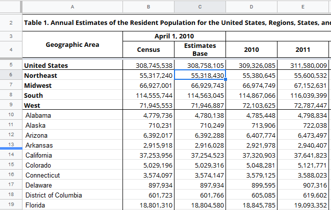

## S2: Look at the end of the rows

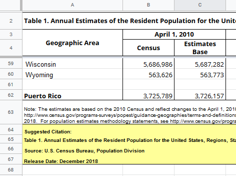

## S2: Look at the end of the rows

Find bottom-right cell coordinate to specify for import

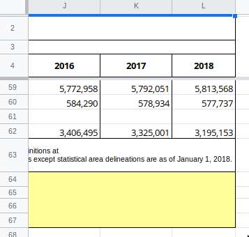

## S2: Read the Excel file again

```r
census_xlsx <- read_excel("data/nst-est2018-01.xlsx", range = "A4:L62")
```

```
New names:
* `` -> ...1
```

## S2: Cleaned but not tidy

- need to rename first column
- columns as years might be ok for some analysis
- "year" column would make date easier to analyze, join to other datasets

## `tidyverse`

Over past ~5 years [tidyverse](https://www.tidyverse.org/)nice cheatsheets [here](https://www.rstudio.com/resources/cheatsheets/) if you're into that has become very popular in data science

Read in data

Then manipulate & plot

## Load `tidyverse`

```r
library("tidyverse")
```

```
── Attaching packages ────────────────────────────────────────────────────────────────── tidyverse 1.2.1 ──
```

```
✔ ggplot2 3.1.1       ✔ purrr   0.3.2
✔ tibble  2.1.1       ✔ dplyr   0.8.0.1
✔ tidyr   0.8.3       ✔ stringr 1.4.0
✔ readr   1.3.1       ✔ forcats 0.4.0
```

```
── Conflicts ───────────────────────────────────────────────────────────────────── tidyverse_conflicts() ──
✖ dplyr::filter() masks stats::filter()
✖ dplyr::lag()    masks stats::lag()
```

## `tidyr` & `dplyr`

### [`tidyr`](https://tidyr.tidyverse.org): reshaping data

- [`gather()`](https://tidyr.tidyverse.org/reference/gather.html) multiple columns to key-value pairs; makes “wide” data longer
- [`drop_na()`](https://tidyr.tidyverse.org/reference/drop_na.html) drops rows with `NA` values

### [`dplyr`](https://dplyr.tidyverse.org): a grammar of data manipulation

- [`select()`](https://dplyr.tidyverse.org/reference/select.html) picks columns based on their names
- [`rename()`](https://dplyr.tidyverse.org/reference/select.htm) renames columns
- [`mutate()`](https://dplyr.tidyverse.org/reference/mutate.html) create or modify data

## `dplyr` concept: pipes

`tidyverse` examples often use pipes

- Borrowed from functional programming / shell languages
- Create effecient, readable chains of functions

```
a %>% b(x) %>% c(y)
```

becomes

```
c(b(a, x), y)
```

## S2: Through the pipes

```r
census_tibb <- census_xlsx %>%
  rename(Region = ...1) %>%
  drop_na() %>%
  select(-one_of(c("Census", "Estimates Base"))) %>%
  gather(`2010`:`2018`, key = year, value = pop_estimate)
```

## S2: Tidy census data

```r
census_tibb
```

| Region | year | pop_estimate |
| --- | --- | --- |
| United States | 2010 | 309326085 |
| Northeast | 2010 | 55380645 |
| Midwest | 2010 | 66974749 |
| South | 2010 | 114867066 |
| West | 2010 | 72103625 |
| .Alabama | 2010 | 4785448 |
| .Alaska | 2010 | 713906 |
| .Arizona | 2010 | 6407774 |
| .Arkansas | 2010 | 2921978 |
| .California | 2010 | 37320903 |

[output cut: 503 more lines]

## S2: Tidy census data

```r
census_tibb$year <- as.numeric(census_tibb$year)
census_tibb
```

| Region | year | pop_estimate |
| --- | --- | --- |
| United States | 2010 | 309326085 |
| Northeast | 2010 | 55380645 |
| Midwest | 2010 | 66974749 |
| South | 2010 | 114867066 |
| West | 2010 | 72103625 |
| .Alabama | 2010 | 4785448 |
| .Alaska | 2010 | 713906 |
| .Arizona | 2010 | 6407774 |
| .Arkansas | 2010 | 2921978 |
| .California | 2010 | 37320903 |

[output cut: 503 more lines]

## S2: All together

```r
census_xlsx %>%
  rename(Region = ...1) %>%
  drop_na() %>%
  select(-one_of(c("Census", "Estimates Base"))) %>%
  gather(`2010`:`2018`, key = year, value = pop_estimate) %>%
  mutate(year = as.integer(year))
```

| Region | year | pop_estimate |
| --- | --- | --- |
| United States | 2010 | 309326085 |
| Northeast | 2010 | 55380645 |
| Midwest | 2010 | 66974749 |
| South | 2010 | 114867066 |
| West | 2010 | 72103625 |
| .Alabama | 2010 | 4785448 |
| .Alaska | 2010 | 713906 |
| .Arizona | 2010 | 6407774 |
| .Arkansas | 2010 | 2921978 |
| .California | 2010 | 37320903 |

[output cut: 503 more lines]

## S3: Sex and Violins

Scenario 3: You're given a summary table to run some linear models on

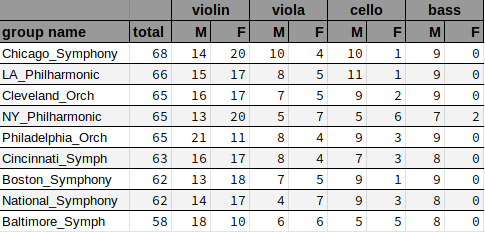

## S3: plain text

The raw text looks like this:

```
Chicago_Symphony  68 14 20 10  4 10  1  9  0

LA_Philharmonic   66 15 17  8  5 11  1  9  0

Cleveland_Orch    65 16 17  7  5  9  2  9  0
...
```

## S3: Column name prep work

```r
inst_types <- c("violin", "viola", "cello", "bass")
sexes <- c("male", "female")
colnames_tmp <- expand.grid(sexes, inst_types)
colnames_tmp
```

| Var1 | Var2 |
| --- | --- |
| male | violin |
| female | violin |
| male | viola |
| female | viola |
| male | cello |
| female | cello |
| male | bass |
| female | bass |

## S3: Generate columns

```r
colnames <- as.vector(mapply(paste, sep="_",
                     colnames_tmp[,1], colnames_tmp[,2]))
colnames <- c("name", "total", colnames)
colnames
```

```
 [1] "name"          "total"         "male_violin"   "female_violin"
 [5] "male_viola"    "female_viola"  "male_cello"    "female_cello"
 [9] "male_bass"     "female_bass"
```

## S3: Read in table

```r
orchest_raw <- read_table("data/symphony.txt", col_names=colnames)
```

```
Parsed with column specification:
cols(
  name = col_character(),
  total = col_double(),
  male_violin = col_double(),
  female_violin = col_double(),
  male_viola = col_double(),
  female_viola = col_double(),
  male_cello = col_double(),
  female_cello = col_double(),
  male_bass = col_double(),
  female_bass = col_double()
)
```

## S3: Examine table

```r
orchest_raw
```

| name | total | male_violin | female_violin | male_viola | female_viola | male_cello | female_cello | male_bass | female_bass |
| --- | --- | --- | --- | --- | --- | --- | --- | --- | --- |
| Chicago_Symphony | 68 | 14 | 20 | 10 | 4 | 10 | 1 | 9 | 0 |
| LA_Philharmonic | 66 | 15 | 17 | 8 | 5 | 11 | 1 | 9 | 0 |
| Cleveland_Orch | 65 | 16 | 17 | 7 | 5 | 9 | 2 | 9 | 0 |
| NY_Philharmonic | 65 | 13 | 20 | 5 | 7 | 5 | 6 | 7 | 2 |
| Philadelphia_Orch | 65 | 21 | 11 | 8 | 4 | 9 | 3 | 9 | 0 |
| Cincinnati_Symph | 63 | 16 | 17 | 8 | 4 | 7 | 3 | 8 | 0 |
| Boston_Symphony | 62 | 13 | 18 | 7 | 5 | 9 | 1 | 9 | 0 |
| National_Symphony | 62 | 14 | 17 | 4 | 7 | 9 | 3 | 8 | 0 |
| Baltimore_Symph | 58 | 18 | 10 | 6 | 6 | 5 | 5 | 8 | 0 |

## S3: Gather and separate

```r
orchestra <- gather(orchest_raw, male_violin:female_bass, key='sex_instrument', value="count")
orchestra <- separate(orchestra, 'sex_instrument', into=c('sex', 'instrument'))
orchestra
```

| name | total | sex | instrument | count |
| --- | --- | --- | --- | --- |
| Chicago_Symphony | 68 | male | violin | 14 |
| LA_Philharmonic | 66 | male | violin | 15 |
| Cleveland_Orch | 65 | male | violin | 16 |
| NY_Philharmonic | 65 | male | violin | 13 |
| Philadelphia_Orch | 65 | male | violin | 21 |
| Cincinnati_Symph | 63 | male | violin | 16 |
| Boston_Symphony | 62 | male | violin | 13 |
| National_Symphony | 62 | male | violin | 14 |
| Baltimore_Symph | 58 | male | violin | 18 |
| Chicago_Symphony | 68 | female | violin | 20 |

[output cut: 62 more lines]

## S3: Dummy variables

- In R, called design matrices
- Make sure desired variables (columns) are factors
- Use `model.matrix`

```r
single_mat <- model.matrix(~instrument, data = orchestra)
head(single_mat)
```

```
  (Intercept) instrumentcello instrumentviola instrumentviolin
1           1               0               0                1
2           1               0               0                1
3           1               0               0                1
4           1               0               0                1
5           1               0               0                1
6           1               0               0                1
```

## S3: Dummy variables

- In R, called design matrices
- Make sure desired variables (columns) are factors
- Use `model.matrix`

## S3: More dummy variables

```r
double_mat <- model.matrix(~instrument+sex, data = orchestra)
head(double_mat)
```

```
  (Intercept) instrumentcello instrumentviola instrumentviolin sexmale
1           1               0               0                1       1
2           1               0               0                1       1
3           1               0               0                1       1
4           1               0               0                1       1
5           1               0               0                1       1
6           1               0               0                1       1
```

## End!

Thanks, questions?